# Practical machine learning: predicting classes of excercise.

Rahul Nayak

01/06/2020

## Background

Using devices such as Jawbone Up, Nike FuelBand, and Fitbit it is now possible to collect a large amount of data about personal activity relatively inexpensively. These type of devices are part of the quantified self movement – a group of enthusiasts who take measurements about themselves regularly to improve their health, to find patterns in their behavior, or because they are tech geeks. One thing that people regularly do is quantify how much of a particular activity they do, but they rarely quantify how well they do it.

In this project, the goal will be to use data from accelerometers on the belt, forearm, arm, and dumbell of 6 participants. They were asked to perform barbell lifts correctly and incorrectly in 5 different ways. More information is available from the website [here.](http://web.archive.org/web/20161224072740/http:/groupware.les.inf.puc-rio.br/har) (see the section on the Weight Lifting Exercise Dataset).

## Data loading and processing

The dataset that is provided is split into test and training datasets.

```r
dat <- read_csv("pml-training.csv")
dat_test<- read_csv("pml-testing.csv")
```

```r
head(dat,2)
```

| X1 | user_name | raw_timestamp_part_1 | raw_timestamp_part_2 | cvtd_timestamp | new_window | num_window | roll_belt | pitch_belt | yaw_belt | total_accel_belt | kurtosis_roll_belt | kurtosis_picth_belt | kurtosis_yaw_belt | skewness_roll_belt | skewness_roll_belt.1 | skewness_yaw_belt | max_roll_belt | max_picth_belt | max_yaw_belt | min_roll_belt | min_pitch_belt | min_yaw_belt | amplitude_roll_belt | amplitude_pitch_belt | amplitude_yaw_belt | var_total_accel_belt | avg_roll_belt | stddev_roll_belt | var_roll_belt | … |
| --- | --- | --- | --- | --- | --- | --- | --- | --- | --- | --- | --- | --- | --- | --- | --- | --- | --- | --- | --- | --- | --- | --- | --- | --- | --- | --- | --- | --- | --- | --- |
| 1 | carlitos | 1323084231 | 788290 | 05/12/2011 11:23 | no | 11 | 1.41 | 8.07 | -94.4 | 3 | NA | NA | NA | NA | NA | NA | NA | NA | NA | NA | NA | NA | NA | NA | NA | NA | NA | NA | NA | … |
| 2 | carlitos | 1323084231 | 808298 | 05/12/2011 11:23 | no | 11 | 1.41 | 8.07 | -94.4 | 3 | NA | NA | NA | NA | NA | NA | NA | NA | NA | NA | NA | NA | NA | NA | NA | NA | NA | NA | NA | … |

There are many variables with majority NA values and they have to be dropped. The colomn types need to be converted to double and the classe column has to be converted to factor.

```r
dat1<-dat[,-c(1:7,12:36,50:59,69:83,87:101,103:112,125:139,141:150)]
dat2<-dat_test[,-c(1:7,12:36,50:59,69:83,87:101,103:112,125:139,141:150)]
```

```r
#converting col types
len<-as.numeric(length(dat1[2,]))
for (n in 2:len-1) {
  dat1[[n]]<-as.numeric(dat1[[n]])
}
dat1[[53]]<-as.factor(dat1[[53]])
```

There might be highly correleted variables and they need to be dropped.

```r
high.correlation <- findCorrelation(cor(dat1[,-53]), 0.90)
dat1<-dat1[,-high.correlation]

high.correlation1 <- findCorrelation(cor(dat2[,]), 0.90)
dat2<-dat2[,-high.correlation]
```

Next the training data has to be split for training and cross-validation.

The training set needs to be large enough to achieve a relatively high accuracy, and the cross validation set also needs to be large enough to give a good indication of the out of sample error.

The training data set was split up into one portion (70%) for model building, model cohort, and another portion (30%) for cross-validation, cross-validation cohort.

```r
#splitting data for cross validation
inTrain <- createDataPartition(dat1$classe, p=.7, list=FALSE)

train<-dat1[inTrain,]
validate<-dat1[-inTrain,]
```

## Model Building

Random forest was chosen as the prediction algorithm used. This model was built on the model cohort and then tested on the cross-validation cohort.

```r
set.seed(46)
model <- train(classe ~., data=train, method="rf", trControl=trainControl(method="cv", verboseIter=TRUE, number=10), ntrees=750)
```

## Confusion Matrix

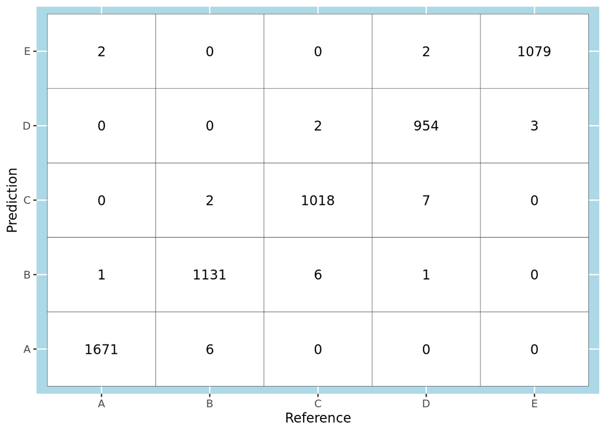

```r
#validation
cross.validation.predict <- predict(model,validate)

#confusion matrix
confusionMatrix <- confusionMatrix(cross.validation.predict, validate$classe)

# Plotting confusion Matrix

cf.table <- as.data.frame(confusionMatrix$table)
ggplot(cf.table, aes(x=Reference, y=Prediction), environment=environment()) +
  geom_tile(fill="white", color="black") +
  geom_text(aes(label=cf.table$Freq)) +
  theme(legend.position="none",  panel.background =element_rect(fill='lightblue') )+
  xlab("Reference") +
  ylab("Prediction")
```

## Accuracy

The random forests model has 99.5% out of sample accuracy, or 0.5% out of sample error.

```r
confusionMatrix$overall
```

```
##       Accuracy          Kappa  AccuracyLower  AccuracyUpper   AccuracyNull
##      0.9945624      0.9931216      0.9923324      0.9962778      0.2844520
## AccuracyPValue  McnemarPValue
##      0.0000000            NaN
```

## Prediction

The model is used to predict classes of the test dataset.

```r
testing.predict <- predict(model, dat2)

testing.predict
```

```
##  [1] B A B A A E D B A A B C B A E E A B B B
## Levels: A B C D E
```